# Prediction Assignment Writeup

YC Chew

January 30, 2016

## Background

Using devices such as Jawbone Up, Nike FuelBand, and Fitbit it is now possible to collect a large amount of data about personal activity relatively inexpensively. These type of devices are part of the quantified self movement – a group of enthusiasts who take measurements about themselves regularly to improve their health, to find patterns in their behavior, or because they are tech geeks. One thing that people regularly do is quantify how much of a particular activity they do, but they rarely quantify how well they do it. In this project, your goal will be to use data from accelerometers on the belt, forearm, arm, and dumbell of 6 participants. They were asked to perform barbell lifts correctly and incorrectly in 5 different ways. More information is available from the website here: http://groupware.les.inf.puc-rio.br/har (see the section on the Weight Lifting Exercise Dataset).

## Data

The training data for this project are available here: https://d396qusza40orc.cloudfront.net/predmachlearn/pml-training.csv

The test data are available here: https://d396qusza40orc.cloudfront.net/predmachlearn/pml-testing.csv

The data for this project come from this source: http://groupware.les.inf.puc-rio.br/har.

The original publication that provide the data: Ugulino, W.; Cardador, D.; Vega, K.; Velloso, E.; Milidiu, R.; Fuks, H. Wearable Computing: Accelerometers’ Data Classification of Body Postures and Movements. Proceedings of 21st Brazilian Symposium on Artificial Intelligence. Advances in Artificial Intelligence - SBIA 2012. In: Lecture Notes in Computer Science. , pp. 52-61. Curitiba, PR: Springer Berlin / Heidelberg, 2012. ISBN 978-3-642-34458-9. DOI: 10.1007/978-3-642-34459-6_6.

## Prepare the data

Reading training and test data from raw files, normalize all ‘NA’, ‘#DIV/0!’ and ‘’ fields as ’NA’.

```r
pml_training <- read.csv("pml-training.csv", na.strings = c("NA", "#DIV/0!", ""))
pml_testing  <- read.csv("pml-testing.csv",  na.strings = c("NA", "#DIV/0!", ""))
```

Review the training data. Same command can apply to the test data set.

```r
str(pml_training)
```

```
## 'data.frame':    19622 obs. of  160 variables:
##  $ X                       : int  1 2 3 4 5 6 7 8 9 10 ...
##  $ user_name               : Factor w/ 6 levels "adelmo","carlitos",..: 2 2 2 2 2 2 2 2 2 2 ...
##  $ raw_timestamp_part_1    : int  1323084231 1323084231 1323084231 1323084232 1323084232 1323084232 1323084232 1323084232 1323084232 1323084232 ...
##  $ raw_timestamp_part_2    : int  788290 808298 820366 120339 196328 304277 368296 440390 484323 484434 ...
##  $ cvtd_timestamp          : Factor w/ 20 levels "02/12/2011 13:32",..: 9 9 9 9 9 9 9 9 9 9 ...
##  $ new_window              : Factor w/ 2 levels "no","yes": 1 1 1 1 1 1 1 1 1 1 ...
##  $ num_window              : int  11 11 11 12 12 12 12 12 12 12 ...
##  $ roll_belt               : num  1.41 1.41 1.42 1.48 1.48 1.45 1.42 1.42 1.43 1.45 ...
##  $ pitch_belt              : num  8.07 8.07 8.07 8.05 8.07 8.06 8.09 8.13 8.16 8.17 ...
##  $ yaw_belt                : num  -94.4 -94.4 -94.4 -94.4 -94.4 -94.4 -94.4 -94.4 -94.4 -94.4 ...
##  $ total_accel_belt        : int  3 3 3 3 3 3 3 3 3 3 ...
##  $ kurtosis_roll_belt      : num  NA NA NA NA NA NA NA NA NA NA ...
##  $ kurtosis_picth_belt     : num  NA NA NA NA NA NA NA NA NA NA ...
##  $ kurtosis_yaw_belt       : logi  NA NA NA NA NA NA ...
```

[output cut: 86 more lines]

## Data cleaning

We might noticed that the first 6 features of data were reference data. Thus, we can remove them as they are no use for prediction.

```r
pml_training <- pml_training[, -c(1:6)]
pml_testing  <- pml_testing[, -c(1:6)]
```

We should remove features with mostly NA values.

```r
# keep features with less than 10% NA in it
good_features  <- apply(!is.na(pml_training), 2, sum) > (0.9 * 19622)
pml_training <- pml_training[, good_features]
pml_testing <- pml_testing[, good_features]
```

```r
# to get the full list of name of those desired features
predNames <- names(pml_training)[grepl('belt|forearm|arm|dumbell', names(pml_training))]
# create final training data with prediction features and the classe feature
pml_training <- pml_training[, c(predNames, 'classe')]
```

## Cross-validation

We split the training set into two for cross validation. We randomly subsample 50% of the set for training purposes and the remaining 50% for testing, evaluation and accuracy measurement.

```r
library(caret)
inTrain <- createDataPartition(y=pml_training$classe, p=0.50, list=FALSE)
pml_train_train  <- pml_training[inTrain, ]
pml_train_validate  <- pml_training[-inTrain, ]
```

## Data modeling

We generate random forest trees from the training dataset using cross-validation.

```r
tr_control <- trainControl(method="cv", number=5, allowParallel=T, verbose=T)
fit_rf <- train(classe~., data=pml_train_train, method="rf", trControl=tr_control, verbose=F)
```

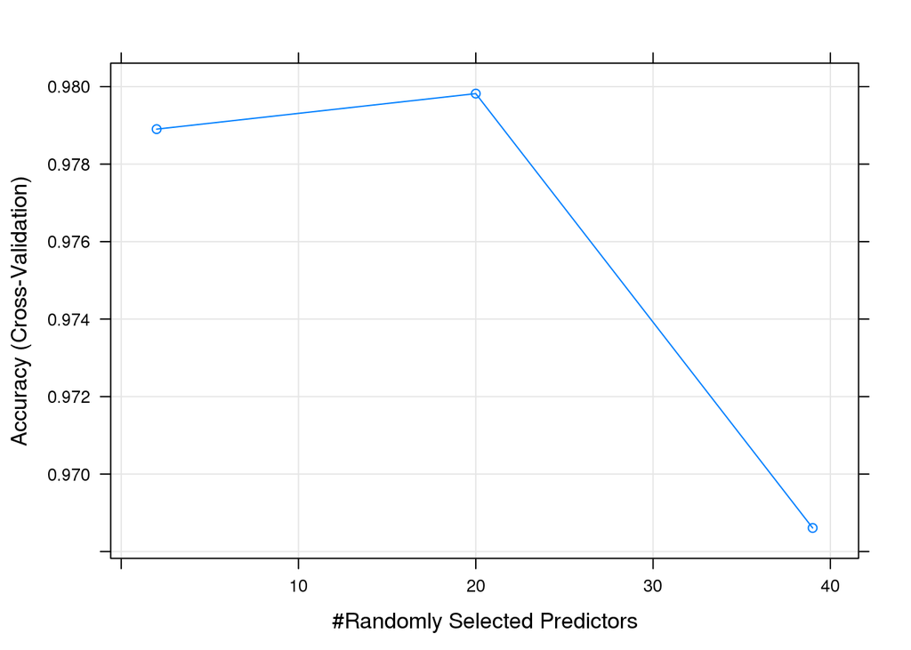

```r
plot(fit_rf)
```

## Out of sample error

```r
predRf <- predict(fit_rf, newdata=pml_train_validate)
cfsm <- confusionMatrix(predRf, pml_train_validate$classe)
cfsm
```

```
## Confusion Matrix and Statistics
##
##           Reference
## Prediction    A    B    C    D    E
##          A 2780   32    3    3    2
##          B   10 1850   38    1    1
##          C    0   16 1647   24    2
##          D    0    0   20 1578   16
##          E    0    0    3    2 1782
##
## Overall Statistics
##
##                Accuracy : 0.9824
##                  95% CI : (0.9796, 0.9849)
##     No Information Rate : 0.2844
##     P-Value [Acc > NIR] : < 2.2e-16
##
##                   Kappa : 0.9777
##  Mcnemar's Test P-Value : 7.687e-06
##
## Statistics by Class:
##
##                      Class: A Class: B Class: C Class: D Class: E
## Sensitivity            0.9964   0.9747   0.9626   0.9813   0.9884
## Specificity            0.9943   0.9937   0.9948   0.9956   0.9994
## Pos Pred Value         0.9858   0.9737   0.9751   0.9777   0.9972
## Neg Pred Value         0.9986   0.9939   0.9921   0.9963   0.9974
## Prevalence             0.2844   0.1935   0.1744   0.1639   0.1838
## Detection Rate         0.2834   0.1886   0.1679   0.1609   0.1817
## Detection Prevalence   0.2875   0.1937   0.1722   0.1645   0.1822
## Balanced Accuracy      0.9954   0.9842   0.9787   0.9885   0.9939
```

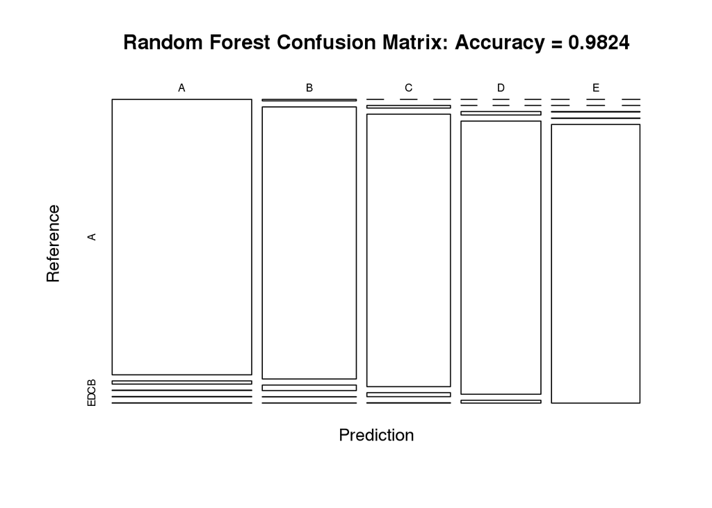

```r
plot(cfsm$table, col = cfsm$byClass, main = paste("Random Forest Confusion Matrix: Accuracy =", round(cfsm$overall['Accuracy'], 4)))
```

## Prediction

We used the above model to predict the 20 test cases.

```r
predResult <- predict(fit_rf, newdata=pml_testing)
# view prediction result
predResult
```

```
##  [1] B A B A A E D B A A B C B A E E A B B B
## Levels: A B C D E
```

```r
# [1] B A B A A E D B A A B C B A E E A B B B
```

## Conclusion

Using the above model, I am able to get 20 out of 20 correct answers for the course project prediction quiz. This confirmed the accuracy of the model.